# Tanzania Modeling Document

#### Prepared by Reduce.Reuse.Grow.Inc

[figure not shown]

## Abstract

RRG has partnered with the Friends of the Usambara (FOU) to conduct Project Forest throughout the Usambara mountains of northeastern Tanzania. RRG and FOU have partnered to plant 6.49 million trees over ~4200 hectares and is planning the expansion of 10 million trees or ~ 6200 hectares. RRG and FOU have conducted forest inventories of diameter at breast height (DBH) and age. Using geospatial data (LiDAR), RRG has trained parametric regression models of forest inventory data to forecast biomass changes per hectare over the project lifetime (50 years). RRG has created a range of quartile based performance scenarios for forecasting biomass changes. In total, RRG estimates that Project Forest can potentially sequester **1,030,776 - 4,123,103 tCo2e** throughout the project lifetime.  
To monitor and quantify biomass change, RRG utilizes Synthetic Aperture Radar (SAR) and LiDAR biomass maps provided by Google Earth Engine (GEE). RRG is able to access a broad range of temporal data and is able to establish the baseline biomass within the project area. As the stand develops, RRG will track biomass changes to train and validate forecasts.

- 1. System Overview
  - 1.1 System Goals
- 2. Data Specifications
  - 2.1 Collection Period
  - 2.2 Coordinate Systems
  - 2.3 Technology Stack
  - 2.4 Workbook Reproduction
- 3. Carbon Removals
  - 3.1 Biomass Training Dataset Collection
  - 3.2 Field Inventories
  - 3.3 Planting Methodology Distinctions
  - 3.4 Model Design
  - 3.5 Model Application
  - 3.6 Ex-Ante Estimates of Biomass Change
- 4. Project Emissions
  - 4.1 Fertilizer Use
  - 4.2 Leakage
- 5. Net Carbon Removals
  - 5.1 Project Instance Breakdown
  - 5.2 Gross Net Carbon Removals
  - 5.3 VCU's Per Year
- 6. Remote Sensing Performance Benchmark
  - 6.1 Modeling of SI at Biomass
    - 6.1.1 Simple Regression
    - 6.1.2 Complex Model
  - 6.2 Baseline Biomass
  - 6.3 Current Biomass
    - 6.3.1 ANOVA Testing
- 7. Model Performance Discussion

## System Overview

#### System Goals

The primary goals of the system are to:

1. Quantify forest biomass and changes using field inventories and remote sensing data.
2. Estimate carbon removals and project emissions (e.g., from planting, fertilizer use and leakage).
3. Calculate net carbon benefits and project future VCUs.
4. Evaluate the performance of machine learning models.

## Data Specifications

#### Collection Period

A 2021 [study](https://www.researchgate.net/publication/356937497_Evaluating_the_impact_of_adaptation_interventions_on_vulnerability_and_livelihood_resilience) by Gaworek, et al. analyzed the eastern Usambara mountains precipitation levels from 1969-2019. Below is the monthly precipitation graph created by the study.

[figure not shown]

The Usambara's have two distinct rainy seasons, from March to May and from September to November. RRG will select imagery for study from the dry season, specifically from December-February in an effort to

- Reduce seasonal phenological variation
- Select months with the lowest cloud cover

#### Coordinate Systems

RRG will utilize two coordinate systems. One geographic coordinate system for web based applications, the other projected coordinate system for area analysis when area quantification must be as accurate as possible:

- Geographic Coordinate System: WGS 1984, EPSG: 4326
- Projected Coordinate System: WGS 1984 UTM Zone 37S, EPSG:32737

#### Technology Stack

RRG will utilize industry standard technologies for data science, remote sensing and forest monitoring. The following technology stack will be used in development and implementation of RRG's modeling system.

**Remote Sensing**

- ArcGIS Pro
- Google Earth Engine [(GEE)](https://developers.google.com/earth-engine/datasets)

**Data Science**

- Python

**Reporting**

- [RRG's dMRV site](https://benparker9.github.io/RRG_dMRV/)
- Jupyter lab Methodology Notebooks

#### Workbook Reproduction

This document provides a reproducible workflow using Python in a Jupyter Notebook environment. The document is rendered in HTML, so code cannot be run. Additionaly due to privacy issues, GEE maps do not render. However, many of the same maps are located at [RRG's dMRV site](https://benparker9.github.io/RRG_dMRV/).  
Auditors may request access to source files (.ipynb, .csv, .tif). Please contact ben@reducereusegrow.org.

```python
import ee
import folium
import geemap
import json
import geopandas as gpd
import numpy as np
import pandas as pd
import seaborn as sns
import matplotlib.pyplot as plt
import os
from IPython.display import Image
import scipy as stats
from lmfit import Model
import statsmodels.api as sm
import statsmodels.formula.api as smf
from statsmodels.formula.api import ols
from scipy.stats import f_oneway
from sklearn.svm import SVR
from sklearn.preprocessing import StandardScaler
from sklearn.pipeline import make_pipeline
from sklearn.metrics import r2_score, mean_squared_error
from sklearn.model_selection import GridSearchCV
from sklearn.linear_model import Ridge
from sklearn.preprocessing import PolynomialFeatures
from sklearn.linear_model import LinearRegression
from sklearn.model_selection import train_test_split
import xgboost as xgb
from mpl_toolkits.mplot3d import Axes3D
import plotly.express as px
import plotly.graph_objects as go
from sklearn.svm import SVR
from sklearn.pipeline import Pipeline
from scipy.stats import f_oneway
pd.set_option('display.max_colwidth', None)
sns.set_theme(palette="Greens")
plt.rcParams.update({
    "font.family": "sans-serif",
    "font.sans-serif": ["Arial", "DejaVu Sans", "Verdana"],
    "figure.facecolor": "#121c16",
    "savefig.facecolor": "#121c16"
})
ee.Authenticate(auth_mode='localhost')
ee.Initialize(project='anacondagee')
```

## Carbon Removals

Per section 8.2.1 of the VM0047 methodology, carbon removals are estimated with the following equations:

[figure not shown]

Section 8.6 of the VM0047 methodology states the criteria to establish ex-ante estimates of carbon removals. Per this guidance, all other carbon pools (SOC, litter, etc.) can be assumed to be 0. The following equations describe how woody biomass removals should be quantified:

[figure not shown]

The ex-ante estimates for the average change in woody biomass will be quantified utilizing RRG's field inventory program.

#### Biomass Training Dataset Collection

**Project Site Shapefiles**  
RRG has preloaded project shapefiles as cloud assests in GEE. Auditors may request access to assets.

```python
projectsites = ee.FeatureCollection('projects/serene-notch-457015-i6/assets/p1zip')
psiteGeom = projectsites.geometry()
usambara = ee.FeatureCollection('projects/serene-notch-457015-i6/assets/usambara_region')
usamGeom = usambara.geometry()
```

**[GEDI Raster ABV Biomass Density (2019-2024)](https://developers.google.com/earth-engine/datasets/catalog/LARSE_GEDI_GEDI04_A_002_MONTHLY#description)**

- Imagery is taken in sampling tracts and is not continuous.
- Imagery is subject to GEDI flightpaths. It is known remote regions are not covered. Data ranges in availability dependent on the year.
- There is little availabale data within the CADT of the OM or within the project zone.
- RRG will use this data set for current biomass estimates.

```python
def quality_mask(im):
    return im.updateMask(im.select('l4_quality_flag').eq(1)) \
             .updateMask(im.select('degrade_flag').eq(0)) \
             .updateMask(im.select('agbd').gt(0))
year = 2020
abgDF = ee.ImageCollection('LARSE/GEDI/GEDI04_A_002_MONTHLY')\
    .filterBounds(projectsites)\
    .filterDate(f'{year}-01-01', f'{year + 1}-04-01')
abgGEDI_geom = abgDF.geometry()
# Mosaic agbd band to a single image AND MULTIPLY BY CARBON FRACTION
abgraw = quality_mask(ee.Image(abgDF.mosaic())).select('agbd').multiply(0.47)
agbGEDI2020 = abgraw.clip(usamGeom)
```

**[Global Aboveground and Belowground Biomass Carbon Density Maps (2010)](https://developers.google.com/earth-engine/datasets/catalog/NASA_ORNL_biomass_carbon_density_v1#bands)**

```python
agbDF2010 = ee.ImageCollection('NASA/ORNL/biomass_carbon_density/v1').filterBounds(projectsites)
agbNASA2010 = agbDF2010.select(['agb', 'bgb']).first().clip(usamGeom)
```

**[WCMC Above and Below Ground Biomass Carbon Density (2010)](https://developers.google.com/earth-engine/datasets/catalog/WCMC_biomass_carbon_density_v1_0#description)**

```python
agbUN = ee.Image('WCMC/biomass_carbon_density/v1_0/2010')
agbUN2010 = agbUN.select('carbon_tonnes_per_ha').clip(usamGeom)
```

**Visualize Results**

```python
#visualization parameters
psiteVis = {
    'fill': 'green'
}
agbVis = {
  'min': 0,
  'max': 500.0,
  'palette': ['d9f0a3', 'addd8e', '78c679', '41ab5d', '238443', '005a32']
}
gediVis = {
  'min': 0,
  'max': 500.0,
  'palette': ['red', 'yellow', 'green']
}
Map = geemap.Map(notebook_display=True)
Map.add_basemap('HYBRID')
Map.addLayer(agbUN2010, agbVis, 'Agb UN 2010')
Map.addLayer(agbNASA2010.select('agb'), agbVis, 'Agb NASA 2010')
Map.addLayer(agbGEDI2020, gediVis, 'Agb GEDI 2020')
Map.addLayer(projectsites, psiteVis, 'Project Sites')
Map.centerObject(projectsites, 10)
Map.add_inspector()
```

[figure not shown]

**Compare Results**

```python
bComps = pd.read_csv('../sheetsTanz/BiomassUsamComparison4.csv') #includes metadata
bComps.head()
bDF = bComps.rename(columns={
    bComps.columns[1]: 'Abv 2010 NASA Biomass',
    bComps.columns[2]: 'Below 2010 NASA Biomass',
    bComps.columns[3]: 'Abv/Below 2010 UN Biomass'
})
bDF['Abv/Below NASA Biomass 2010'] = bDF.iloc[:, 1] + bDF.iloc[:, 2]
bDF.head(1) #visualize raw data
```

|  | system:index | Abv 2010 NASA Biomass | Below 2010 NASA Biomass | Abv/Below 2010 UN Biomass | .geo | Abv/Below NASA Biomass 2010 |
| --- | --- | --- | --- | --- | --- | --- |
| 0 | 0 | 9.7325 | 2.93 | 12.522223 | {"type":"Point","coordinates":[38.47669047252213,-4.743807446649259]} | 12.6625 |

```python
bDF1 = bDF.iloc[:,[-1, -3]]
bDF1.describe()
```

|  | Abv/Below NASA Biomass 2010 | Abv/Below 2010 UN Biomass |
| --- | --- | --- |
| count | 10000.000000 | 10000.000000 |
| mean | 38.258159 | 36.117243 |
| std | 21.516966 | 21.367189 |
| min | 4.716500 | 2.236111 |
| 25% | 21.829576 | 19.167361 |
| 50% | 35.157999 | 33.171825 |
| 75% | 48.552999 | 46.537499 |
| max | 121.830799 | 133.155563 |

**Selected Biomass Source**  
GEDI data is sparse within the Usambara mountains. Therefore, RRG will use the dataset's provided by the UN and NASA for field inventory training. Between these sources, old growth forests throughout the region range from 120 - 140 tC/ha. For inventory model training, RRG has selected a biological cap ~ 140 tC/ha. For SI model training, RRG utilizies all three biomass datasets.

#### Field Inventories

RRG and FOU conducted initial field inventories of species to be planted. Because GEE datasets do not provide forest age data, RRG can use inventory data to forecast carbon removals throughout the project lifetime.
RRG will first convert DBH to mass (t) by utilizing allometric equations. RRG then models age and biomass data to predict potential biomass of the site throughout the project lifetime. The following equation describes the model: $$ \text{Biomass (kg/tree)} = f(\text{Age}) $$

```python
field_df = pd.read_csv('./sheetsTanz/YIELD.csv').iloc[:,0:3].round()
field_df.sample(5)
```

|  | Latin_Name | Age | DBH |
| --- | --- | --- | --- |
| 151 | Syzgium sp. | 6.0 | 6.0 |
| 13 | Bridelia micrantha | 6.0 | 10.0 |
| 65 | Grevillea robusta | 56.0 | 61.0 |
| 152 | Syzgium sp. | 7.0 | 10.0 |
| 39 | Croton megalocarpus | 5.0 | 7.0 |

**Allometric Conversion**  
To convert DBH into aboveground weight (kg), RRG has conducted a thorough analysis of allometric equations for the Usambara region. RRG chose the most conservative allometric equation created for the Usambara region provided by [R.E. Malimbwi](https://www.suaire.sua.ac.tz/server/api/core/bitstreams/0b52d41d-d1a0-409a-b3f7-631b706124f9/content).

```python
def allo(x):
    eq = (( 0.9635 * x ** 1.9440 ) * .001)
    return(eq)
inv_df = field_df.iloc[:,[1,2]]
inv_df['Biomass_t'] = allo(field_df['DBH']).round(decimals=2)
inv_df = inv_df.iloc[:,[0,2]]
inv_df.head(2)
```

|  | Age | Biomass_t |
| --- | --- | --- |
| 0 | 15.0 | 0.36 |
| 1 | 30.0 | 1.93 |

**Quick Look at Data Distributions**  
Quick look function to understand correlations, standard deviations and distributions.

```python
def ql(data):
    df = data.iloc[:, [0,1]]
    x = df.iloc[:,0]
    y = df.iloc[:,1]
    xName = df.columns[0]
    yName = df.columns[1]
    #Statistics
    df.corr()
    spearman_corr = x.corr(y, method='spearman')
    print('Spearman Correlation:', spearman_corr)
    # Calculate standard deviations
    std_x = df[xName].std()
    std_y = df[yName].std()
    # Create text for standard deviation
    textstrx = f'Standard Deviation of\n{xName}: {std_x:.2f}'
    textstry = f'Standard Deviation of\n{yName}: {std_y:.2f}'
    props = dict(boxstyle='round', facecolor='grey', alpha=0.5)
    # statistical graphs
    sns.set_theme()
    fig, axs = plt.subplots(2, 2, figsize=(10, 8))
    axs = axs.flatten()
    #Scatter plot distribution
    sns.scatterplot(x = f"{xName}", y = f"{yName}", data = df, alpha=0.5, color='purple', ax=axs[0])
    axs[0].set_title('Scatter Plot')
    axs[0].set_xlabel(f'{xName}')
    axs[0].set_ylabel(f'{yName}')
    #heatmap of correlations
    sns.heatmap(df.corr(), annot=True, cmap='coolwarm', ax=axs[1], cbar=True, cbar_kws={"label": "Correlation Coefficient"})
    axs[1].set_title('Correlation Heatmap')
    # hist plot
    sns.histplot(df[f"{xName}"], kde=True, color="darkgreen", ax=axs[2])
    axs[2].set_title(f'Distribution of {xName}')
    axs[2].set_xlabel(f'{xName}')
    axs[2].text(0.98, 0.95, textstrx, transform=axs[2].transAxes, fontsize=8,
        verticalalignment='top', bbox=props, horizontalalignment='right')
    sns.histplot(df[f"{yName}"], kde=True, color="darkgreen", ax=axs[3])
    axs[3].set_title(f'Distribution of {yName}')
    axs[3].text(0.98, 0.95, textstry, transform=axs[3].transAxes, fontsize=8,
        verticalalignment='top', bbox=props, horizontalalignment='right')
    axs[3].set_xlabel(f'{yName}')
    fig.suptitle(f'Distribution of {xName} and {yName}')
    plt.tight_layout(rect=[0, 0.03, 1, 0.92], pad=1.0)
    plt.show()
```

```
Spearman Correlation: 0.8140328253791882
```

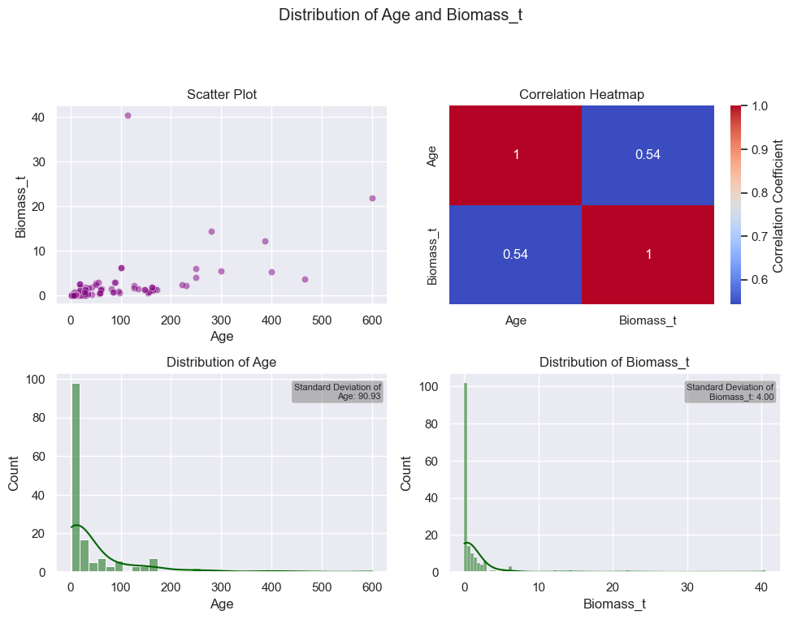

```
None
```

```python
print(ql(inv_df))
```

#### Project Instance Distinctions

**Planting Density**  
FOU is planting with the same density compositions through project instance 1 and 2. Below is the density composition and total estimated hectares planted for each methodology:

```python
method_df = pd.DataFrame({
    'Method' : ['Instance 1', 'Instance 2'],
    'Density' : [1600, 1600],
    'Ha Planted' : [4200, 6200]
})
```

**Applying Known Biomass Cielings**  
Given the LiDAR biomass studies found in the training dataset analysis, the maximum biomass in Usambara ranges from 120-140 tC/ha. Below RRG quantifies the maximum per tree biomass given the biological cieling.

```python
maxbiomass = 140
method_df['Maximum Single Tree Biomass'] = maxbiomass / method_df.iloc[:, 1]
method_df.head()
```

|  | Method | Density | Ha Planted | Maximum Single Tree Biomass |
| --- | --- | --- | --- | --- |
| 0 | Instance 1 | 1600 | 4200 | 0.0875 |
| 1 | Instance 2 | 1600 | 6200 | 0.0875 |

#### Model Design

RRG has created a parametric regression modeling function to be used for carbon forecasts. The function utilizes 2nd Polynomial, 3rd Polynomial, Logarithmic, Power and Chapman-Richard's equations to predict biomass given age. Included in the function are statistical metrics including R2, RMSE and MPE to track model quality.

```python
def model(data):
    df = data.copy()
    x = df.iloc[:, 0]
    y = df.iloc[:, 1]
    xName = df.columns[0]
    yName = df.columns[1]
    # PARAMETRIC MODELING
    #linear modeling/polynomial
    results = smf.wls(f'{yName} ~ {xName}', data=df, weights=df['weights']).fit()
    poly2 = smf.wls(f'{yName} ~ {xName} + I({xName}**2)', data=df, weights=df['weights']).fit()
    poly3 = smf.wls(f'{yName} ~ {xName} + I({xName}**2) + I({xName}**3)', data=df, weights=df['weights']).fit()
    #non linear with including log, power, exponential, chapman richards
    def power(x, a,b):
        return a * x**b
    powerModel = Model(power)
    pParams = powerModel.make_params(a=0.5, b=1)
    pParams['a'].set(min=0)
    pParams['b'].set(min=0)
    pResult = powerModel.fit(df[f'{yName}'], pParams, x =df[f'{xName}'], weights=df['weights'])
    def CR(x, a, b, c):
        return a * (1 - np.exp(-b * x))**c
    CRModel = Model(CR)
    CRParams = CRModel.make_params(a=(df[f'{yName}'].max()), b=0.03, c=2)
    CRParams['a'].set(min=0)
    CRParams['b'].set(min=0)
    CRParams['c'].set(min=0)
    CRResult = CRModel.fit(df[f'{yName}'].values, CRParams, x=df[f'{xName}'].values, nan_policy='omit', weights=df['weights'])
    def log(x, a, b):
        return a * np.log(x) + b
    logModel = Model(log)
    lParams = logModel.make_params(a=0.5, b=1)
    lResult = logModel.fit(df[f'{yName}'], lParams, x=df[f'{xName}'], nan_policy='omit', weights=df['weights'])

    # QUICK LOOK TO COMPARE MODEL OUTCOMES
    # Mean Percentage Error
    def mean_percentage_error(y_true, y_pred):
        y_true, y_pred = np.array(y_true), np.array(y_pred)
        nonzero_mask = y_true != 0
        if not np.any(nonzero_mask):
        # All y_true are zero, can't compute MPE
            return np.nan
        mpe = np.mean((y_true[nonzero_mask] - y_pred[nonzero_mask]) / y_true[nonzero_mask]) * 100
        return mpe
    def evaluate_model(name, y_true, y_pred, formula):
        return {
        'Model': name,
        'Formula': formula,
        'R²': r2_score(y_true, y_pred),
        'RMSE': np.sqrt(mean_squared_error(y_true, y_pred)),
        'MPE': mean_percentage_error(y_true, y_pred)
    }
    results_list = []
    y_pred_linear = results.predict(df)
    formula_linear = f"{yName} = {results.params['Intercept']:.3f} + {results.params[xName]:.3f} * {xName}"
    results_list.append(evaluate_model('Linear', df[yName], y_pred_linear, formula_linear))
    y_pred_poly2 = poly2.predict(df)
    formula_poly2 = (f"{yName} = {poly2.params['Intercept']:.3f} + "
                 f"{poly2.params[xName]:.3f} * {xName} + "
                 f"{poly2.params[f'I({xName} ** 2)']:.3f} * {xName}²")
    results_list.append(evaluate_model('Polynomial (2nd)', df[yName], y_pred_poly2, formula_poly2))
    y_pred_poly3 = poly3.predict(df)
    formula_poly3 = (f"{yName} = {poly3.params['Intercept']:.3f} + "
                 f"{poly3.params[xName]:.3f} * {xName} + "
                 f"{poly3.params[f'I({xName} ** 2)']:.3f} * {xName}² + "
                 f"{poly3.params[f'I({xName} ** 3)']:.3f} * {xName}³")
    results_list.append(evaluate_model('Polynomial (3rd)', df[yName], y_pred_poly3, formula_poly3))
    y_pred_log = lResult.eval(x=df[xName])
    aL = lResult.params['a'].value
    bL = lResult.params['b'].value
    formula_log = f"{yName} = {aL:.3f} * ln({xName}) + {bL:.3f}"
    results_list.append(evaluate_model('Logarithmic', df[yName], y_pred_log, formula_log))
    y_pred_power = pResult.eval(x=df[xName])
    aP = pResult.params['a'].value
    bP = pResult.params['b'].value
    formula_power = f"{yName} = {aP:.14f} * {xName} ^ {bP:.3f}"
    results_list.append(evaluate_model('Power', df[yName], y_pred_power, formula_power))
    y_pred_CR = CRResult.eval(x=df[xName])
    aCR = CRResult.params['a'].value
    bCR = CRResult.params['b'].value
    cCR = CRResult.params['c'].value
    formula_CR = f"{yName} = {aCR:.3f} * (1 - exp(-{bCR:.3f} * {xName})) ^ {cCR:.3f}"
    results_list.append(evaluate_model('Chapman-Richards', df[yName], y_pred_CR, formula_CR))
    metrics_df = pd.DataFrame(results_list)
    metrics_df = metrics_df.sort_values(by='R²', ascending=False).reset_index(drop=True)


    #GRAPH RESULTS
    # Create x values
    x_vals = np.linspace(1.3 * df[xName].min(), 1.3 * df[xName].max(), 200)
    # Scatter plots of original data
    fig, axs = plt.subplots(1, 2, figsize=(12, 6))
    axs[0].scatter(df[xName], df[yName], label='Inventory Data', color='blue', alpha=0.6, s=20)
    axs[1].scatter(df[xName], df[yName], label='Inventory Data', color='blue', alpha=0.6, s=15)
    # Linear
    y_vals_linear = results.params['Intercept'] + results.params[xName] * x_vals
    axs[0].plot(x_vals, y_vals_linear, label='Linear', color='blue', linestyle='-')
    axs[1].plot(x_vals, y_vals_linear, label='Linear', color='blue', linestyle='-')
    # Polynomial 2nd degree
    y_vals_poly2 = (poly2.params['Intercept']
                + poly2.params[xName] * x_vals
                + poly2.params[f'I({xName} ** 2)'] * x_vals**2)
    axs[0].plot(x_vals, y_vals_poly2, label='Polynomial (2nd)', color='green', linestyle='--')
    axs[1].plot(x_vals, y_vals_poly2, label='Polynomial (2nd)', color='green', linestyle='--')
    # Polynomial 3rd degree
    y_vals_poly3 = (
    poly3.params['Intercept']
    + poly3.params[xName] * x_vals
    + poly3.params[f'I({xName} ** 2)'] * x_vals**2
    + poly3.params[f'I({xName} ** 3)'] * x_vals**3
    )
    axs[0].plot(x_vals, y_vals_poly3, label='Polynomial (3rd)', color='darkgreen', linestyle=':')
    axs[1].plot(x_vals, y_vals_poly3, label='Polynomial (3rd)', color='darkgreen', linestyle=':')
    # Power
    aP = pResult.params['a'].value
    bP = pResult.params['b'].value
    y_vals_power = aP * x_vals**bP
    axs[0].plot(x_vals, y_vals_power, label='Power', color='purple', linestyle='-.', linewidth = 2)
    axs[1].plot(x_vals, y_vals_power, label='Power', color='purple', linestyle='-.', linewidth = 2)
    # Logarithmic (only valid for x_vals > 0)
    x_vals_log = x_vals[x_vals > 0]
    y_vals_log = lResult.params['a'].value * np.log(x_vals_log) + lResult.params['b'].value
    axs[0].plot(x_vals_log, y_vals_log, label='Logarithmic', color='orange', linestyle='--')
    axs[1].plot(x_vals_log, y_vals_log, label='Logarithmic', color='orange', linestyle='--')
    # Chapman-Richards
    aCR = CRResult.params['a'].value
    bCR = CRResult.params['b'].value
    cCR = CRResult.params['c'].value
    y_vals_CR = aCR * (1 - np.exp(-bCR * x_vals))**cCR
    axs[0].plot(x_vals, y_vals_CR, label='Chapman-Richards', color='brown', linestyle='-.')
    axs[1].plot(x_vals, y_vals_CR, label='Chapman-Richards', color='brown', linestyle='-.')
    # Final plot formatting
    axs[0].set_ylim(-5, 45)
    axs[0].set_xlim(0,(1.2*df[xName].max()))
    axs[1].set_ylim(-.01, .4)
    axs[1].set_xlim(0,50)
    for ax in axs.flat:
        ax.set(xlabel='Age', ylabel='Biomass per Tree (tC)')
    plt.suptitle('Predicting Biomass per Tree Given Inventory Data')
    plt.legend()
    plt.show()
    return metrics_df
```

```python
# add weights for project instance 1 & 2 with same max single tree biomass
p = inv_df.copy()
p['weights'] = np.where(p['Biomass_t'] < 0.2, 10000, 1) #RRG tested different values for training
p.sample(5)
```

|  | Age | Biomass_t | weights |
| --- | --- | --- | --- |
| 125 | 134.0 | 1.51 | 1 |
| 101 | 162.0 | 1.79 | 1 |
| 144 | 2.0 | 0.03 | 10000 |
| 27 | 30.0 | 1.19 | 1 |
| 62 | 57.0 | 0.39 | 1 |

#### Model Application

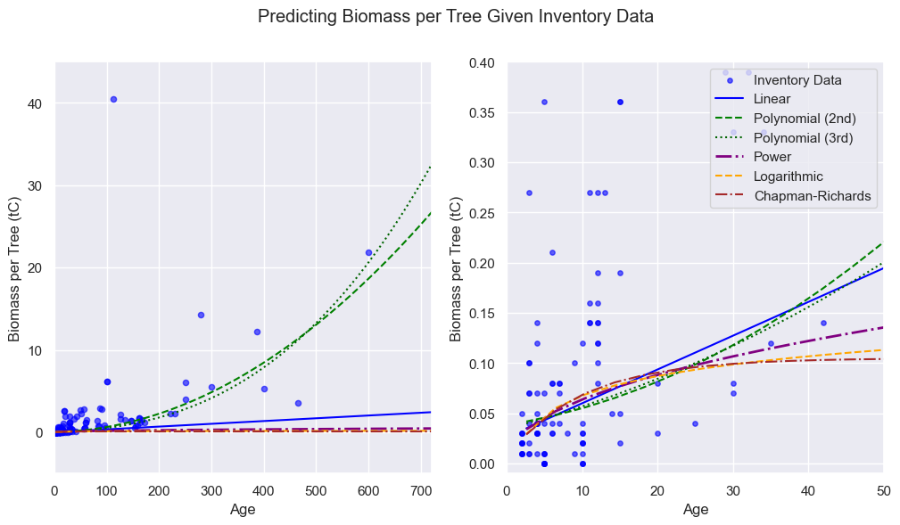

|  | Model | Formula | R² | RMSE | MPE |
| --- | --- | --- | --- | --- | --- |
| 0 | Polynomial (2nd) | Biomass_t = 0.039 + 0.001 * Age + 0.000 * Age² | 0.246530 | 3.459520 | -13.988290 |
| 1 | Polynomial (3rd) | Biomass_t = 0.035 + 0.002 * Age + 0.000 * Age² + 0.000 * Age³ | 0.234976 | 3.485943 | -9.632663 |
| 2 | Linear | Biomass_t = 0.026 + 0.003 * Age | 0.005610 | 3.974305 | 3.052945 |
| 3 | Power | Biomass_t = 0.02170433564523 * Age ^ 0.468 | -0.063828 | 4.110727 | 7.368384 |
| 4 | Logarithmic | Biomass_t = 0.028 * ln(Age) + 0.002 | -0.078787 | 4.139527 | 11.150352 |
| 5 | Chapman-Richards | Biomass_t = 0.105 * (1 - exp(-0.091 * Age)) ^ 0.831 | -0.084707 | 4.150870 | 11.873930 |

```python
metrics_df = model(p)
metrics_df.head(6)
```

**Model Selection**  
RRG has chosen the Chapman-Richard's sigmoid curve for lifecycle modeling. RRG understands model tests indicate low model performance. Because RRG heavily weighed the lower portion of the dataset, all statistical tests are expected to be negatively impacted. Moving into the future, RRG and PEF will collect additional inventory data to strengthen model results.

```python
def biomass_t(Age):
    biomass =  0.105 * (1 - np.exp(-0.091 * Age)) ** 0.831
    return(biomass)
```

#### Ex-Ante Estimates of Biomass Change

**Biomass Scaling**  
The modeling process above quantifies the estimated average single tree biomass. To quantify the per hectare biomass, these values must be scaled by density (trees/hectare).

```python
method_df.head() #to see below .iloc
```

|  | Method | Density | Ha Planted | Maximum Single Tree Biomass |
| --- | --- | --- | --- | --- |
| 0 | Instance 1 | 1600 | 4200 | 0.0875 |
| 1 | Instance 2 | 1600 | 6200 | 0.0875 |

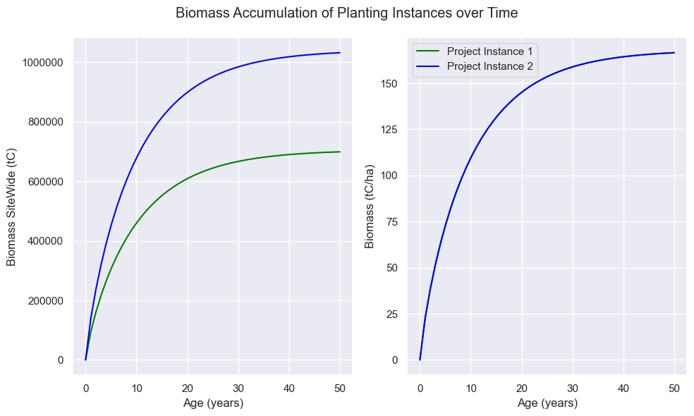

```python
x1 = np.linspace(0,50, 50)
p1Ha = biomass_t(x1) * method_df.iloc[0,1]
p2Ha = biomass_t(x1) * method_df.iloc[1,1]
p1Site = p1Ha * method_df.iloc[0,2]
p2Site = p2Ha * method_df.iloc[1,2]
fig, axs = plt.subplots(1, 2, figsize=(10, 6))
axs[1].plot(x1, p1Ha, label='Project Instance 1', color='green')
axs[1].plot(x1, p2Ha, label='Project Instance 2', color='blue')
axs[0].plot(x1, p1Site, label='Project Instance 1', color='green')
axs[0].plot(x1, p2Site, label='Project Instance 2', color='blue')
for ax in axs.flat:
    ax.set(xlabel='Age (years)')
    ax.ticklabel_format(style='plain', axis='both')
axs[0].set_ylabel('Biomass SiteWide (tC)')
axs[1].set_ylabel('Biomass (tC/ha)')
plt.suptitle('Biomass Accumulation of Planting Instances over Time')
plt.grid(True)
plt.legend()
plt.tight_layout()
plt.show()
```

**Estimated Carbon Removals per Project Instance**

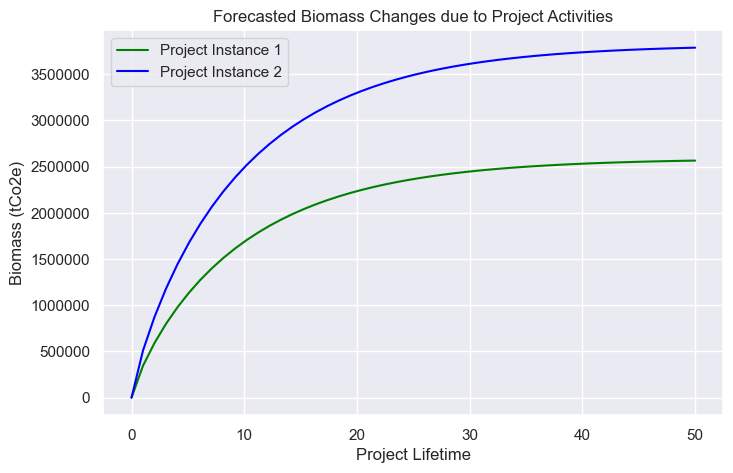

```python
pInstance1 = p1Site * (44/12)
pInstance2 = p2Site * (44/12)
plt.figure(figsize=(8,5))
plt.plot(x1, pInstance1, label='Project Instance 1', color = 'green')
plt.plot(x1, pInstance2, label='Project Instance 2', color = 'blue')
plt.title('Forecasted Biomass Changes due to Project Activities')
plt.xlabel('Project Lifetime')
plt.ylabel('Biomass (tCo2e)')
plt.ticklabel_format(style='plain', axis='y')
plt.legend()
plt.show()
```

#### Quantifying Uncertainty with Quartile-Based Performance Scenarios

- Low Performing Models (25%)
- Mid Performing Models (50-75%)
- High Performing Models (100%)

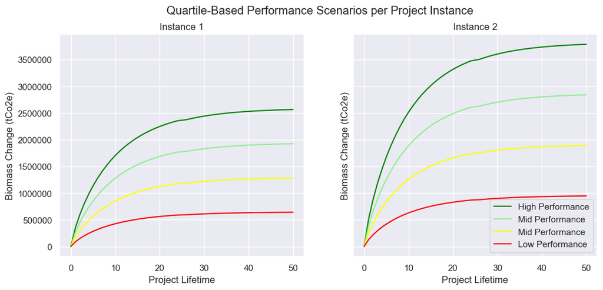

```python
netRemovals_p1 = pd.DataFrame({
    'Year' : np.round(x1),
    'High_Co2e': pInstance1,
    'Mid1_Co2e': pInstance1 * 0.75,
    'Mid2_Co2e': pInstance1 * 0.5,
    'Low_Co2e': pInstance1 * 0.25
})
netRemovals_p2 = pd.DataFrame({
    'Year' : np.round(x1),
    'High_Co2e': pInstance2,
    'Mid1_Co2e': pInstance2 * 0.75,
    'Mid2_Co2e': pInstance2 * 0.5,
    'Low_Co2e': pInstance2 * 0.25
})
fig, axs = plt.subplots(1, 2, figsize=(12, 5), sharey=True)
axs[0].plot(netRemovals_p1.iloc[:,0], netRemovals_p1.iloc[:,1], label='High Performance', color = 'green')
axs[0].plot(netRemovals_p1.iloc[:,0], netRemovals_p1.iloc[:,2], label='Mid Performance', color = 'lightgreen')
axs[0].plot(netRemovals_p1.iloc[:,0], netRemovals_p1.iloc[:,3], label='Mid Performance', color = 'yellow')
axs[0].plot(netRemovals_p1.iloc[:,0], netRemovals_p1.iloc[:,4], label='Low Performance', color = 'red')
axs[0].set_title('Instance 1')
axs[1].plot(netRemovals_p2.iloc[:,0], netRemovals_p2.iloc[:,1], label='High Performance', color = 'green')
axs[1].plot(netRemovals_p2.iloc[:,0], netRemovals_p2.iloc[:,2], label='Mid Performance', color = 'lightgreen')
axs[1].plot(netRemovals_p2.iloc[:,0], netRemovals_p2.iloc[:,3], label='Mid Performance', color = 'yellow')
axs[1].plot(netRemovals_p2.iloc[:,0], netRemovals_p2.iloc[:,4], label='Low Performance', color = 'red')
axs[1].set_title('Instance 2')
for ax in axs.flat:
    ax.set(xlabel='Project Lifetime', ylabel='Biomass Change (tCo2e)')
plt.suptitle('Quartile-Based Performance Scenarios per Project Instance')
plt.ticklabel_format(style='plain', axis='y')
plt.legend()
plt.show()
```

## Project Emissions

Per section 8.2.2 of the VM0047 methodology, project emissions result from biomass burning and fertilizer use. FOU will not burn any land nor use fertilizer, so project emissions are 0 (de mimis). If FOU changes it's methodologies, RRG will quantify FOU's emissions. The below equation summarizes project emissions:

[figure not shown]

### Leakage

The Lushoto district has minimal available data regarding historical grower records and illegal logging rates. RRG can see from remote sensing that farms throughout the project zone are quite small and are believed to be subsistence farms.  
Moving into the future, RRG and FOU will complete the FPIC process and hold local farmer interviews to determine foregone production within the project area. It is not anticipated that project activities will not displace any farms within the project area. FOU aims to mitigate leakage into the surrounding region by employing these farmers and providing them with an alternate, sustainable livelihood.  
Until the FPIC process occurs, RRG has decided to implement the default leakage deductions set out in the Verra Standard, v4.7. These deductions are taken from the gross Co2e removals and are 15% from activity shifting leakage and 10% from market shifting leakage.  
RRG will ultimately use the VM0054 ARR Leakage module to calculate leakage. This module first estimates leakage by calculating production (based on grower records), an anticipated amount of new land brought into production and the determination of the change in carbon stock due to this land change. Cumulatively, the following equation describes how RRG will quantify leakage.

[figure not shown]

For ex-ante estimations, leakage must be quantified in tCo2. To do this with the default 25% rate, RRG takes 25% of total Co2e removals from each performance scenario.

```python
def leak(mass):
    metric = mass * 0.25
    return(metric)
```

## Net Carbon Removals

Per section 8.5 of the VM0047 methodology, net carbon removals are quantified as follows:

[figure not shown]

**Uncertainty**  
Currently, RRG is using the default uncertainty rate of 10%. Moving into the future, RRG will quantify uncertainty utilizing equation 27 of the VM0047 methodology.

```python
unc = .1
```

**Performance Benchmark**  
Because project activities have just begun, RRG is not currently able to quantify the performance benchmark metric. For ex-ante net carbon removals, RRG has chosen a value of 0. In the immediate future, RRG will complete the performance benchmark analysis.

```python
PB = 0
```

#### Project Instance Breakdown

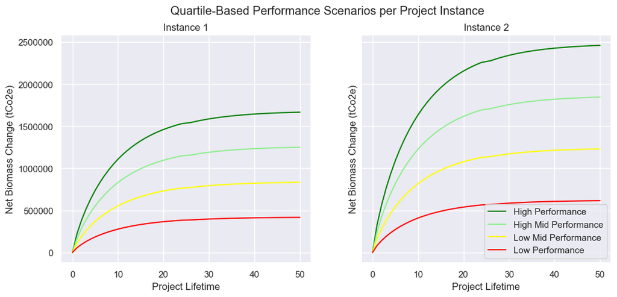

```python
# quantify net removals
#p1 calc
netRemovals_p1['Net Co2e Removals High'] = ((netRemovals_p1.iloc[:,1] * (1- PB) * (1-unc))\
                                     - leak(netRemovals_p1.iloc[:,1]))
netRemovals_p1['Net Co2e Removals Upper Mid'] = ((netRemovals_p1.iloc[:,2] * (1- PB) * (1-unc))\
                                     - leak(netRemovals_p1.iloc[:,2]))
netRemovals_p1['Net Co2e Removals Lower Mid'] = ((netRemovals_p1.iloc[:,3] * (1- PB) * (1-unc))\
                                     - leak(netRemovals_p1.iloc[:,3]))
netRemovals_p1['Net Co2e Removals Low'] = ((netRemovals_p1.iloc[:,4] * (1- PB) * (1-unc))\
                                     - leak(netRemovals_p1.iloc[:,4]))
# p2 calc
netRemovals_p2['Net Co2e Removals High'] = ((netRemovals_p2.iloc[:,1] * (1- PB) * (1-unc))\
                                     - leak(netRemovals_p2.iloc[:,1]))
netRemovals_p2['Net Co2e Removals Upper Mid'] = ((netRemovals_p2.iloc[:,2] * (1- PB) * (1-unc))\
                                     - leak(netRemovals_p2.iloc[:,2]))
netRemovals_p2['Net Co2e Removals Lower Mid'] = ((netRemovals_p2.iloc[:,3] * (1- PB) * (1-unc))\
                                     - leak(netRemovals_p2.iloc[:,3]))
netRemovals_p2['Net Co2e Removals Low'] = ((netRemovals_p2.iloc[:,4] * (1- PB) * (1-unc))\
                                     - leak(netRemovals_p2.iloc[:,4]))
#plot
fig, axs = plt.subplots(1, 2, figsize=(12, 5), sharey=True)
axs[0].plot(netRemovals_p1.iloc[:,0], netRemovals_p1.iloc[:,-4], label='High Performance', color = 'green')
axs[0].plot(netRemovals_p1.iloc[:,0], netRemovals_p1.iloc[:,-3], label='High Mid Performance', color = 'lightgreen')
axs[0].plot(netRemovals_p1.iloc[:,0], netRemovals_p1.iloc[:,-2], label='Low Mid Performance', color = 'yellow')
axs[0].plot(netRemovals_p1.iloc[:,0], netRemovals_p1.iloc[:,-1], label='Low Performance', color = 'red')
axs[0].set_title('Instance 1')
axs[1].plot(netRemovals_p2.iloc[:,0], netRemovals_p2.iloc[:,-4], label='High Performance', color = 'green')
axs[1].plot(netRemovals_p2.iloc[:,0], netRemovals_p2.iloc[:,-3], label='High Mid Performance', color = 'lightgreen')
axs[1].plot(netRemovals_p2.iloc[:,0], netRemovals_p2.iloc[:,-2], label='Low Mid Performance', color = 'yellow')
axs[1].plot(netRemovals_p2.iloc[:,0], netRemovals_p2.iloc[:,-1], label='Low Performance', color = 'red')
axs[1].set_title('Instance 2')
for ax in axs.flat:
    ax.set(xlabel='Project Lifetime', ylabel='Net Biomass Change (tCo2e)')
plt.suptitle('Quartile-Based Performance Scenarios per Project Instance')
plt.ticklabel_format(style='plain', axis='y')
plt.legend()
plt.show()
```

#### Gross Net Carbon Removals

RRG assumes that project instance 1 begins in year 0, while project instance 2 will start in year 3. In total, RRG estimates that Project Forest can potentially sequester **1,030,776 - 4,123,103 tCo2e** throughout the project lifetime.

```python
# select each table merge together
p1 = netRemovals_p1.iloc[:, [0,-4,-3,-2,-1]]
p2 = netRemovals_p2.iloc[:,-4:]
zero_rows = pd.DataFrame(0, index=range(3), columns=p2.columns)
# Concatenate the new rows above the existing data
p2_total = pd.concat([zero_rows, p2], ignore_index=True)
p2_total['Year'] = range(0, len(p2_total))
total = pd.merge(p1, p2_total, on='Year', suffixes=('_p1', '_p2'))
total.head()
```

|  | Year | Net Co2e Removals High_p1 | Net Co2e Removals Upper Mid_p1 | Net Co2e Removals Lower Mid_p1 | Net Co2e Removals Low_p1 | Net Co2e Removals High_p2 | Net Co2e Removals Upper Mid_p2 | Net Co2e Removals Lower Mid_p2 | Net Co2e Removals Low_p2 |
| --- | --- | --- | --- | --- | --- | --- | --- | --- | --- |
| 0 | 0.0 | 0.000000 | 0.000000 | 0.000000 | 0.000000 | 0.00000 | 0.000000 | 0.00000 | 0.000000 |
| 1 | 1.0 | 224580.231865 | 168435.173899 | 112290.115933 | 56145.057966 | 0.00000 | 0.000000 | 0.00000 | 0.000000 |
| 2 | 2.0 | 384733.744788 | 288550.308591 | 192366.872394 | 96183.436197 | 0.00000 | 0.000000 | 0.00000 | 0.000000 |
| 3 | 3.0 | 519258.718971 | 389444.039228 | 259629.359485 | 129814.679743 | 0.00000 | 0.000000 | 0.00000 | 0.000000 |
| 4 | 4.0 | 635854.672739 | 476891.004554 | 317927.336369 | 158963.668185 | 331523.19942 | 248642.399565 | 165761.59971 | 82880.799855 |

```python
projectSums = total.copy()
projectSums['Net Co2e Removals High'] = projectSums.iloc[:,1] + projectSums.iloc[:,5]
projectSums['Net Co2e Removals Mid High'] = projectSums.iloc[:,2] + projectSums.iloc[:,6]
projectSums['Net Co2e Removals Mid Low'] = projectSums.iloc[:,3] + projectSums.iloc[:,7]
projectSums['Net Co2e Removals Low'] = projectSums.iloc[:,4] + projectSums.iloc[:,8]
projectSums = projectSums.iloc[:, [0,-4,-3,-2,-1]]
projectSums.tail()
```

|  | Year | Net Co2e Removals High | Net Co2e Removals Mid High | Net Co2e Removals Mid Low | Net Co2e Removals Low |
| --- | --- | --- | --- | --- | --- |
| 45 | 46.0 | 4.104608e+06 | 3.078456e+06 | 2.052304e+06 | 1.026152e+06 |
| 46 | 47.0 | 4.109896e+06 | 3.082422e+06 | 2.054948e+06 | 1.027474e+06 |
| 47 | 48.0 | 4.114713e+06 | 3.086035e+06 | 2.057357e+06 | 1.028678e+06 |
| 48 | 49.0 | 4.119103e+06 | 3.089327e+06 | 2.059552e+06 | 1.029776e+06 |
| 49 | 50.0 | 4.123103e+06 | 3.092327e+06 | 2.061551e+06 | 1.030776e+06 |

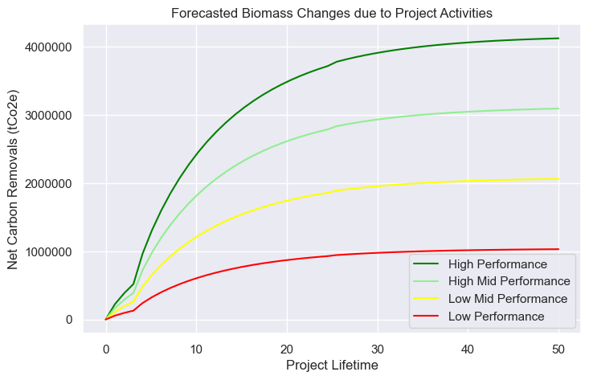

```python
plt.figure(figsize=(8,5))
plt.plot(x1, projectSums.iloc[:,1], label='High Performance', color = 'green')
plt.plot(x1, projectSums.iloc[:,2], label='High Mid Performance', color = 'lightgreen')
plt.plot(x1, projectSums.iloc[:,3], label='Low Mid Performance', color = 'yellow')
plt.plot(x1, projectSums.iloc[:,4], label='Low Performance', color = 'red')
plt.title('Forecasted Biomass Changes due to Project Activities')
plt.xlabel('Project Lifetime')
plt.ylabel('Net Carbon Removals (tCo2e)')
plt.ticklabel_format(style='plain', axis='y')
plt.legend()
plt.show()
```

#### VCU's Per Year

With the Chapman-Richards curve, RRG is estimating that planted stands will be fast growing and reach maturity around year 30. RRG and PEF will conduct future field inventories to validate and update current assumptions.

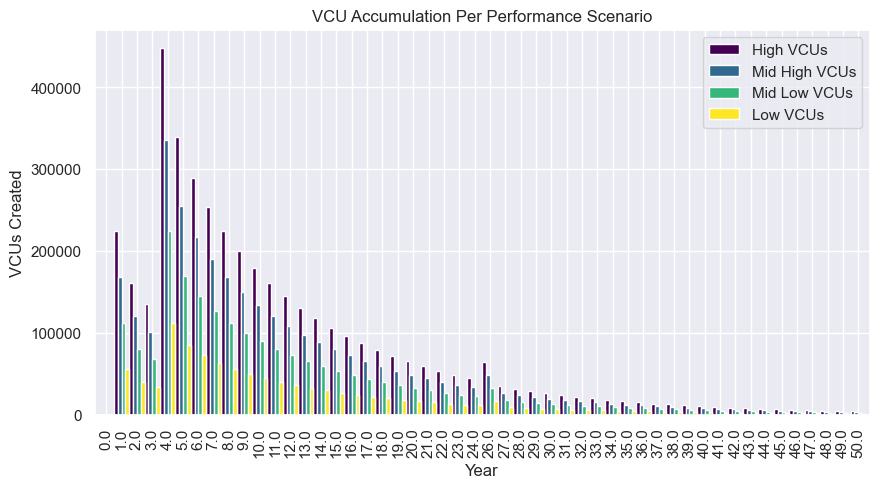

```python
vcu = projectSums.copy()
vcu['High VCUs'] = vcu.iloc[:,1].diff()
vcu['Mid High VCUs'] = vcu.iloc[:,2].diff()
vcu['Mid Low VCUs'] = vcu.iloc[:,3].diff()
vcu['Low VCUs'] = vcu.iloc[:,4].diff()
vcuDF = vcu.iloc[:,[0,-4,-3,-2,-1]]
vcuDF.iloc[:,0] = vcuDF.iloc[:,0].round()
# Set index to Year
vcuDF.set_index('Year', inplace=True)
vcuDF.plot(kind='bar', stacked=False, figsize=(10,5), colormap='viridis', width=1.0)
plt.title('VCU Accumulation Per Performance Scenario')
plt.xlabel('Year')
plt.ylabel('VCUs Created')
plt.show()
```

```python
# test .diff() methodology to make sure diff sums = gross total
test = vcu.copy()
test.loc[0, 'High VCUs'] = projectSums.iloc[0, 1]
# Now cumulative sum
test['High VCUs CumSum'] = test['High VCUs'].cumsum()
test.loc[0, 'Mid High VCUs'] = projectSums.iloc[0, 2]
test['Mid High VCUs CumSum'] = test['Mid High VCUs'].cumsum()
test.loc[0, 'Mid Low VCUs'] = projectSums.iloc[0, 3]
test['Mid Low VCUs CumSum'] = test['Mid Low VCUs'].cumsum()
test.loc[0, 'Low VCUs'] = projectSums.iloc[0, 4]
test['Low VCUs CumSum'] = test['Low VCUs'].cumsum()
test.tail()
```

|  | Year | Net Co2e Removals High | Net Co2e Removals Mid High | Net Co2e Removals Mid Low | Net Co2e Removals Low | High VCUs | Mid High VCUs | Mid Low VCUs | Low VCUs | High VCUs CumSum | Mid High VCUs CumSum | Mid Low VCUs CumSum | Low VCUs CumSum |
| --- | --- | --- | --- | --- | --- | --- | --- | --- | --- | --- | --- | --- | --- |
| 45 | 46.0 | 4.104608e+06 | 3.078456e+06 | 2.052304e+06 | 1.026152e+06 | 5804.174560 | 4353.130920 | 2902.087280 | 1451.043640 | 4.104608e+06 | 3.078456e+06 | 2.052304e+06 | 1.026152e+06 |
| 46 | 47.0 | 4.109896e+06 | 3.082422e+06 | 2.054948e+06 | 1.027474e+06 | 5288.016381 | 3966.012286 | 2644.008191 | 1322.004095 | 4.109896e+06 | 3.082422e+06 | 2.054948e+06 | 1.027474e+06 |
| 47 | 48.0 | 4.114713e+06 | 3.086035e+06 | 2.057357e+06 | 1.028678e+06 | 4817.879814 | 3613.409860 | 2408.939907 | 1204.469953 | 4.114713e+06 | 3.086035e+06 | 2.057357e+06 | 1.028678e+06 |
| 48 | 49.0 | 4.119103e+06 | 3.089327e+06 | 2.059552e+06 | 1.029776e+06 | 4389.640804 | 3292.230603 | 2194.820402 | 1097.410201 | 4.119103e+06 | 3.089327e+06 | 2.059552e+06 | 1.029776e+06 |
| 49 | 50.0 | 4.123103e+06 | 3.092327e+06 | 2.061551e+06 | 1.030776e+06 | 3999.548433 | 2999.661325 | 1999.774217 | 999.887108 | 4.123103e+06 | 3.092327e+06 | 2.061551e+06 | 1.030776e+06 |

## Remote Sensing Performance Benchmark

### Modeling of SI at Biomass

RRG has compared a range of stocking indices (SI) to monitor biomass accumulation. Below RRG compares a simple and complex biomass model.

#### Simple Regression

[SAR backscatter](https://developers.google.com/earth-engine/datasets/catalog/JAXA_ALOS_PALSAR_YEARLY_SAR) images are representations of the microwave portion of the electromagnetic spectrum. SAR data is commonly used for [detecting forest changes](https://earthdata.nasa.gov/s3fs-public/2025-04/SARHB_CH3_Content.pdf) and is less suceptible to seasonal variations. The following equation sums the model: $$ \text{Biomass} = f(\text{SAR HV}) $$ $$ \text{where Biomass = WCMC Aboveground and Belowground Biomass} $$

```python
def SI_model(data):
    df = data.copy()
    x = df.iloc[:, 0]
    y = df.iloc[:, 1]
    xName = df.columns[0]
    yName = df.columns[1]
    # PARAMETRIC MODELING
    #linear modeling/polynomial
    results = smf.wls(f'{yName} ~ {xName}', data=df).fit()
    poly2 = smf.wls(f'{yName} ~ {xName} + I({xName}**2)', data=df).fit()
    poly3 = smf.wls(f'{yName} ~ {xName} + I({xName}**2) + I({xName}**3)', data=df).fit()
    # QUICK LOOK TO COMPARE MODEL OUTCOMES
    # Mean Percentage Error
    def mean_percentage_error(y_true, y_pred):
        y_true, y_pred = np.array(y_true), np.array(y_pred)
        nonzero_mask = y_true != 0
        if not np.any(nonzero_mask):
        # All y_true are zero, can't compute MPE
            return np.nan
        mpe = np.mean((y_true[nonzero_mask] - y_pred[nonzero_mask]) / y_true[nonzero_mask]) * 100
        return mpe
    def evaluate_model(name, y_true, y_pred, formula):
        return {
        'Model': name,
        'Formula': formula,
        'R²': r2_score(y_true, y_pred),
        'RMSE': np.sqrt(mean_squared_error(y_true, y_pred)),
        'MPE': mean_percentage_error(y_true, y_pred)
    }
    results_list = []
    y_pred_linear = results.predict(df)
    formula_linear = f"{yName} = {results.params['Intercept']:.3f} + {results.params[xName]:.3f} * {xName}"
    results_list.append(evaluate_model('Linear', df[yName], y_pred_linear, formula_linear))
    y_pred_poly2 = poly2.predict(df)
    formula_poly2 = (f"{yName} = {poly2.params['Intercept']:.3f} + "
                 f"{poly2.params[xName]:.3f} * {xName} + "
                 f"{poly2.params[f'I({xName} ** 2)']:.3f} * {xName}²")
    results_list.append(evaluate_model('Polynomial (2nd)', df[yName], y_pred_poly2, formula_poly2))
    y_pred_poly3 = poly3.predict(df)
    formula_poly3 = (f"{yName} = {poly3.params['Intercept']:.3f} + "
                 f"{poly3.params[xName]:.3f} * {xName} + "
                 f"{poly3.params[f'I({xName} ** 2)']:.3f} * {xName}² + "
                 f"{poly3.params[f'I({xName} ** 3)']:.3f} * {xName}³")
    results_list.append(evaluate_model('Polynomial (3rd)', df[yName], y_pred_poly3, formula_poly3))
    metrics_df = pd.DataFrame(results_list)
    metrics_df = metrics_df.sort_values(by='R²', ascending=False).reset_index(drop=True)
    #GRAPH RESULTS
    # Create x values
    x_vals = np.linspace(1.3 * df[xName].min(), 1.3 * df[xName].max(), 200)
    # Scatter plots of original data
    plt.figure(figsize=(12, 6))
    plt.scatter(df[xName], df[yName], label='GEE Data', color='lightblue', alpha=0.6, s=20)
    # Linear
    y_vals_linear = results.params['Intercept'] + results.params[xName] * x_vals
    plt.plot(x_vals, y_vals_linear, label='Linear', color='blue', linestyle='-')
    # Polynomial 2nd degree
    y_vals_poly2 = (poly2.params['Intercept']
                + poly2.params[xName] * x_vals
                + poly2.params[f'I({xName} ** 2)'] * x_vals**2)
    plt.plot(x_vals, y_vals_poly2, label='Polynomial (2nd)', color='green', linestyle='--')
    # Polynomial 3rd degree
    y_vals_poly3 = (
    poly3.params['Intercept']
    + poly3.params[xName] * x_vals
    + poly3.params[f'I({xName} ** 2)'] * x_vals**2
    + poly3.params[f'I({xName} ** 3)'] * x_vals**3
    )
    plt.plot(x_vals, y_vals_poly3, label='Polynomial (3rd)', color='darkgreen', linestyle=':')
    # Final plot formatting
    plt.ylim(-1, (1.2*df[yName].max()))
    plt.xlim((1.2* df[xName].min()), (1.2*df[xName].max()))
    plt.xlabel('HV Index Value (dB)')
    plt.ylabel('Biomass per ha (tC)')
    plt.title('Predicting Biomass per Hectare Given SAR HV Data')
    plt.legend()
    plt.show()
    return metrics_df
```

**Data Collection**

```python
# FOR SAR DATA COLLECTION
year = 2010
palsar = ee.ImageCollection('JAXA/ALOS/PALSAR/YEARLY/SAR_EPOCH')\
  .filterDate(f'{year}-01-01', f'{year}-04-01').filterBounds(projectsites)
print(palsar.size().getInfo())
def applyQualityMask(image):
    # Assuming 'MSK' is the data quality mask band
    msk = image.select('qa')
    # Mask out pixels with value 50 (commonly water/invalid in ALOS PALSAR)
    mask = msk.neq(50)
    masked_image = image.updateMask(mask)
    return masked_image
def convertToGammaNaught(image):
    # Convert DN to gamma naught (γ₀) in decibels
    gamma_naught = image.pow(2).log10().multiply(10).subtract(83)
    return gamma_naught
collection = (
    palsar
    .map(convertToGammaNaught)  # Convert DN to gamma naught
    .map(applyQualityMask)
)
palsarImage = collection.median().clip(usamGeom)
hvImage = palsarImage.select('HV') #Users can select
#HH or HV to compare. RRG compared and HV was shown to be the best index for Mindanao
hvVis = {
  'min': -30,
  'max': 0,
  'palette': ['red', 'yellow', 'green']
}
SARMap = geemap.Map(notebook_display=True)
SARMap.add_basemap('HYBRID')
SARMap.addLayer(hvImage, hvVis, 'HV 2010 (db)')
SARMap.addLayer(agbUN2010, agbVis, 'Agb UN 2010')
SARMap.addLayer(projectsites, psiteVis, 'Project Sites')
SARMap.centerObject(projectsites, 10)
SARMap.add_inspector()
```

```
1
```

[figure not shown]

**Dataset Cleaning and Quick Look**  
This raw dataset includes each sampled point, including the coordinates. Auditors can cross reference each sampled point in the mapping app of their choice.  
There are differing resolutions between AGB datasets (300m) and SAR HH datasets (25m). So, there are many HH measurements per AGB measurement. To smoothe this, RRG has taken the mean of all HH values at each AGB value.

```python
sar_df = pd.read_csv('./sheetsTanz/HVBiomass2010_v1.csv')
sar_df.head(1)
```

|  | system:index | HV | agb | carbon_tonnes_per_ha | .geo |
| --- | --- | --- | --- | --- | --- |
| 0 | 0 | -19.659564 | 9.7325 | 12.522223 | {"type":"Point","coordinates":[38.47669047252213,-4.743807446649259]} |

```
Spearman Correlation: 0.7974788489892728
```

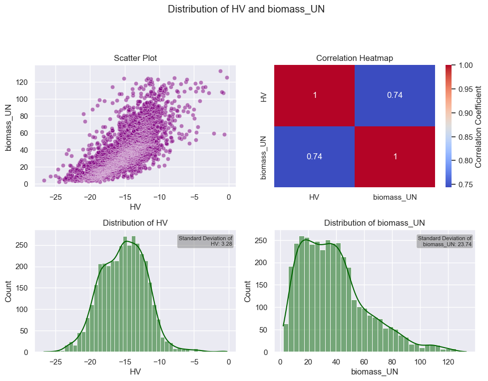

```
None
```

```python
rawSAR = sar_df.iloc[:, [1, 3]]
rawSAR.columns.values[1] = 'biomass_UN'
rawSAR = rawSAR.round(2)
dfSAR = rawSAR.groupby('biomass_UN')['HV'].mean().reset_index()
dfSAR = dfSAR.iloc[:, [1,0]]
print(ql(dfSAR))
```

#### Model Application

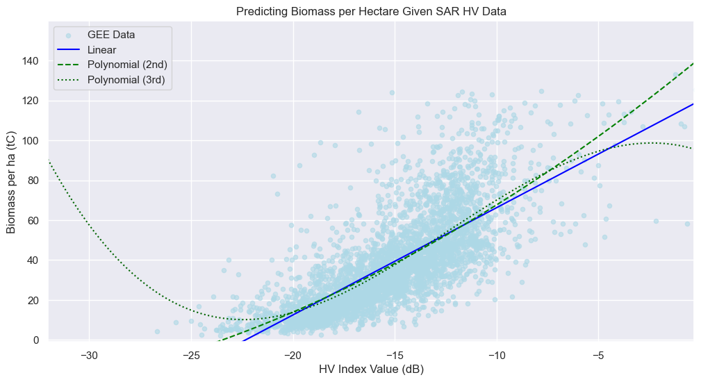

|  | Model | Formula | R² | RMSE | MPE |
| --- | --- | --- | --- | --- | --- |
| 0 | Polynomial (3rd) | biomass_UN = 94.641 + -3.516 * HV + -0.817 * HV² + -0.022 * HV³ | 0.569972 | 15.565559 | -19.598687 |
| 1 | Polynomial (2nd) | biomass_UN = 141.260 + 8.360 * HV + 0.100 * HV² | 0.557889 | 15.782716 | -18.843882 |
| 2 | Linear | biomass_UN = 119.984 + 5.375 * HV | 0.552946 | 15.870710 | -16.983067 |

```python
metrics_df = SI_model(dfSAR)
metrics_df
```

**Model Selection**  
When comparing model results and curve shapes, RRG chose the 2nd Polynomial equation for export due to it's high end (100-140ha) biomass estimates. Moving into the future, RRG will add additional biomass datasets to refine these models.

```python
def biomass_HV(HV):
    biomass = 141.26 + 8.36 * HV + 0.1 * HV**2
    return(biomass)
```

#### Complex Model

**Model Design**  
RRG has chosen to compare multiple linear regression and support vector regression models.

```python
def mlr(data):
    df = data.copy()
    features = ['NDVI', 'HV']
    x = df[features]
    y = df.iloc[:,0]
    # Split dataset (80% train, 20% test)
    X_train, X_test, y_train, y_test = train_test_split(x, y, test_size=0.3, random_state=42)
    # Scale features
    scaler = StandardScaler()
    X_train_scaled = scaler.fit_transform(X_train)
    X_test_scaled = scaler.transform(X_test)
    # Initialize and train model
    model = LinearRegression()
    model.fit(X_train_scaled, y_train)
    # Predict on test data
    y_pred = model.predict(X_test_scaled)
    reg_model_diff = pd.DataFrame({'Actual value': y_test, 'Predicted value': y_pred})
    # Calculate residuals
    residuals = y_test - y_pred
    # Evaluation
    print("Intercept:", model.intercept_)
    print("Coefficients:", list(zip(x.columns, model.coef_)))
    print("R² on test set:", r2_score(y_test, y_pred))
    print("MSE on test set:", mean_squared_error(y_test, y_pred))
    print("RMSE on test set:", np.sqrt(mean_squared_error(y_test, y_pred)))
    # graph results
    # Create meshgrid for surface
    x1_range = np.linspace(X_train_scaled[:, 0].min(), X_train_scaled[:, 0].max(), 50)
    x2_range = np.linspace(X_train_scaled[:, 1].min(), X_train_scaled[:, 1].max(), 50)
    X1_mesh, X2_mesh = np.meshgrid(x1_range, x2_range)
    grid_points = np.c_[X1_mesh.ravel(), X2_mesh.ravel()]
    y_pred_mesh = model.predict(grid_points).reshape(X1_mesh.shape)
    # Inverse transform for better axis labels
    grid_points_unscaled = scaler.inverse_transform(grid_points)
    X1_unscaled = grid_points_unscaled[:, 0].reshape(X1_mesh.shape)
    X2_unscaled = grid_points_unscaled[:, 1].reshape(X2_mesh.shape)
    X_train_inv = scaler.inverse_transform(X_train_scaled)
    # Plot with Plotly
    fig = go.Figure()
    # Add training data points
    fig.add_trace(go.Scatter3d(
        x=X_train_inv[:, 0], y=X_train_inv[:, 1], z=y_train,
        mode='markers',
        marker=dict(size=5, color='blue', opacity=0.7),
        name='Train Data'
    ))
    # Add prediction surface
    fig.add_trace(go.Surface(
        x=X1_unscaled,
        y=X2_unscaled,
        z=y_pred_mesh,
        colorscale='Viridis',
        opacity=0.6,
        name='Regression Plane'
    ))
    fig.update_layout(
        scene=dict(
            xaxis_title=features[0],
            yaxis_title=features[1],
            zaxis_title='Biomass'
        ),
        title="3D Linear Regression with Prediction Surface",
        width=800,
        height=500
    )
    fig.show()
```

```python
def svr(data):
    df = data.copy()
    features = ['NDVI', 'HV']
    x = df[features]
    y = df.iloc[:,0]
    # Split dataset (80% train, 20% test)
    X_train, X_test, y_train, y_test = train_test_split(x, y, test_size=0.3, random_state=42)
    # Scale features
    scaler = StandardScaler()
    X_train_scaled = scaler.fit_transform(X_train)
    X_test_scaled = scaler.transform(X_test)
    # Initialize and train model
    model = SVR(kernel='rbf', C=10, epsilon=.1, gamma=.5)
    model.fit(X_train_scaled, y_train)
    # Predict on test data
    y_pred = model.predict(X_test_scaled)
    print("R² on test set:", r2_score(y_test, y_pred))
    print("MSE on test set:", mean_squared_error(y_test, y_pred))
    print("RMSE on test set:", np.sqrt(mean_squared_error(y_test, y_pred)))
    # graph results
    # Create meshgrid for surface
    x1_range = np.linspace(X_train_scaled[:, 0].min(), X_train_scaled[:, 0].max(), 50)
    x2_range = np.linspace(X_train_scaled[:, 1].min(), X_train_scaled[:, 1].max(), 50)
    X1_mesh, X2_mesh = np.meshgrid(x1_range, x2_range)
    grid_points = np.c_[X1_mesh.ravel(), X2_mesh.ravel()]
    y_pred_mesh = model.predict(grid_points).reshape(X1_mesh.shape)
    # Inverse transform for better axis labels
    grid_points_unscaled = scaler.inverse_transform(grid_points)
    X1_unscaled = grid_points_unscaled[:, 0].reshape(X1_mesh.shape)
    X2_unscaled = grid_points_unscaled[:, 1].reshape(X2_mesh.shape)
    X_train_inv = scaler.inverse_transform(X_train_scaled)
    # Plot with Plotly
    fig = go.Figure()
    # Add training data points
    fig.add_trace(go.Scatter3d(
        x=X_train_inv[:, 0], y=X_train_inv[:, 1], z=y_train,
        mode='markers',
        marker=dict(size=5, color='blue', opacity=0.7),
        name='Train Data'
    ))
    # Add prediction surface
    fig.add_trace(go.Surface(
        x=X1_unscaled,
        y=X2_unscaled,
        z=y_pred_mesh,
        colorscale='Viridis',
        opacity=0.6,
        name='Regression Plane'
    ))
    fig.update_layout(
        scene=dict(
            xaxis_title=features[0],
            yaxis_title=features[1],
            zaxis_title='Biomass'
        ),
        title="3D Support Vector Regression with Prediction Surface",
        width=800,
        height=500
    )
    fig.show()
```

**Data Collection**

```python
# FOR SAR DATA COLLECTION
year = 2010
palsar = ee.ImageCollection('JAXA/ALOS/PALSAR/YEARLY/SAR_EPOCH')\
  .filterDate(f'{year}-01-01', f'{year}-02-01').filterBounds(projectsites)
print(palsar.size().getInfo())
def applyQualityMask(image):
    # Assuming 'MSK' is the data quality mask band
    msk = image.select('qa')
    # Mask out pixels with value 50 (commonly water/invalid in ALOS PALSAR)
    mask = msk.neq(50)
    masked_image = image.updateMask(mask)
    return masked_image
def convertToGammaNaught(image):
    # Convert DN to gamma naught (γ₀) in decibels
    gamma_naught = image.pow(2).log10().multiply(10).subtract(83)
    return gamma_naught
collection = (
    palsar
    .map(convertToGammaNaught)  # Convert DN to gamma naught
    .map(applyQualityMask)
)
palsarImage = collection.median().clip(usamGeom)
hvImage = palsarImage.select('HV')
hhImage = palsarImage.select('HH')
# NDVI collection
landsat = ee.ImageCollection('LANDSAT/LE07/C02/T1_L2')\
    .filterDate(f'{year}-12-01', f'{year + 1}-02-01').filterBounds(projectsites)
print(landsat.size().getInfo())
def scale_sr(img):
    red = img.select('SR_B3').multiply(0.0000275).add(-0.2).rename('RED')
    nir = img.select('SR_B4').multiply(0.0000275).add(-0.2).rename('NIR')
    return img.addBands([red, nir], overwrite=True)
def mask_l7_sr(image):
    qa = image.select('QA_PIXEL')
    mask = qa.bitwiseAnd(1 << 0).eq(0)   \
           .And(qa.bitwiseAnd(1 << 3).eq(0))  \
           .And(qa.bitwiseAnd(1 << 5).eq(0))
    return image.updateMask(mask)
# Apply to each image
scaled_collection = landsat.map(scale_sr).map(mask_l7_sr)
# Median composite
image = scaled_collection.median().clip(usamGeom)
# Calculate NDVI
ndvi = image.normalizedDifference(['NIR', 'RED']).rename('NDVI')

# SLOPE COLLECTION
dem = ee.Image("USGS/SRTMGL1_003")
terrain = ee.Terrain.products(dem)
slope = terrain.select('slope')
slope = slope.clip(usamGeom)
#viz parameters
hvVis = {
  'min': -30,
  'max': 0,
  'palette': ['red', 'yellow', 'green']
}
ndviVis = {'min': 0, 'max': 1, 'palette': ['red', 'yellow', 'green']}
slopeVis = {'min': 0, 'max': 100, 'palette': ['white', 'green', 'brown']}
#map
SARMap = geemap.Map(notebook_display=True)
SARMap.add_basemap('HYBRID')
SARMap.addLayer(hvImage, hvVis, 'HV 2010 (db)')
SARMap.addLayer(hhImage, hvVis, 'HH 2010 (db)')
SARMap.addLayer(agbUN2010, agbVis, 'Agb UN 2010')
SARMap.addLayer(ndvi, ndviVis, 'NDVI 2010')
SARMap.addLayer(slope, slopeVis, 'slope 2010')
SARMap.addLayer(projectsites, psiteVis, 'Project Sites')
SARMap.centerObject(projectsites, 10)
SARMap.add_inspector()
```

```
1
2
```

[figure not shown]

**Load and Visualize Dataset**

```python
data = pd.read_csv('./sheetsPhil/complexModel2010_v1.csv')
raw = data.iloc[:, 1:6]
def ql_complex(data):
    sns.set_theme()
    sns.heatmap(data.corr(), annot=True, cmap='coolwarm', cbar=True, cbar_kws={"label": "Correlation Coefficient"})
    sns.pairplot(data, height=3.7, aspect=1)
model_df = raw.iloc[:, [3,0,1,2,4]]
model_df.describe()
```

|  | carbon_tonnes_per_ha | HH | HV | NDVI | slope |
| --- | --- | --- | --- | --- | --- |
| count | 610.000000 | 610.000000 | 610.000000 | 610.000000 | 610.000000 |
| mean | 63.134885 | -7.170164 | -13.507994 | 0.693002 | 11.473770 |
| std | 42.584351 | 2.533256 | 2.688518 | 0.161392 | 9.516046 |
| min | 0.311111 | -19.948118 | -27.180230 | -0.154353 | 0.000000 |
| 25% | 27.799583 | -8.731871 | -15.180415 | 0.589137 | 4.000000 |
| 50% | 55.006109 | -7.054650 | -13.381188 | 0.734012 | 9.000000 |
| 75% | 92.547291 | -5.719573 | -11.668894 | 0.824953 | 17.000000 |
| max | 187.461655 | 4.399152 | -6.345991 | 0.950817 | 49.000000 |

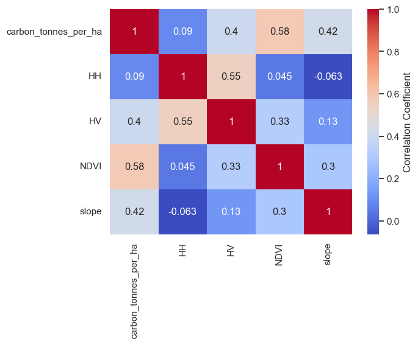

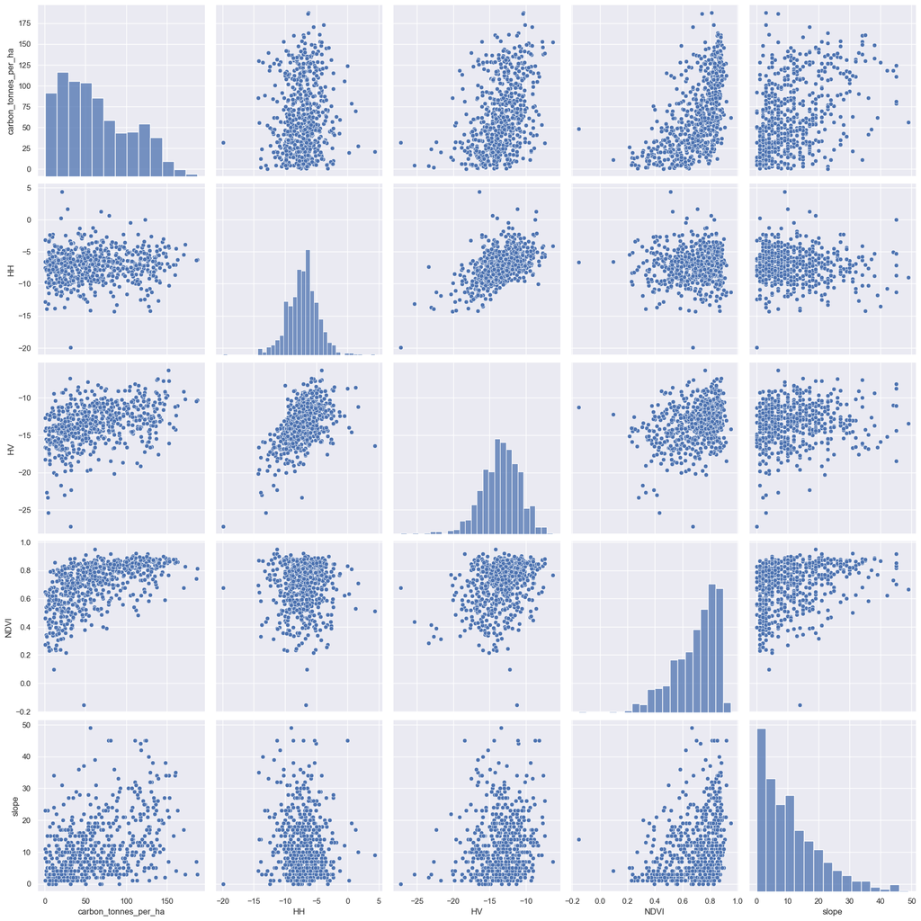

```python
ql_complex(model_df)
```

**Model Application**

```
Intercept: 63.4821663926022
Coefficients: [('NDVI', np.float64(20.631248186768175)), ('HV', np.float64(9.822123916536832))]
R² on test set: 0.4168877758535612
MSE on test set: 1101.7907605041337
RMSE on test set: 33.19323365543245
```

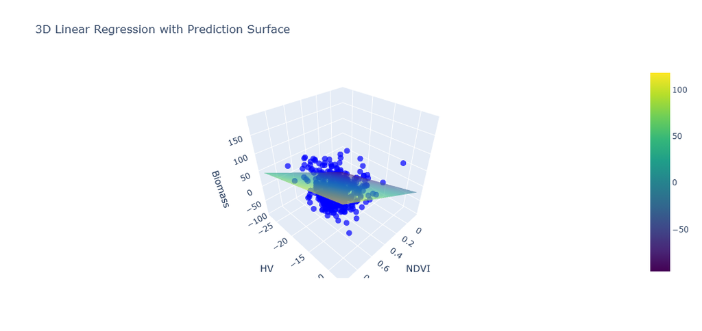

```python
mlr(model_df)
```

```
R² on test set: 0.3961959227306113
MSE on test set: 1140.8880245375651
RMSE on test set: 33.77703398076221
```

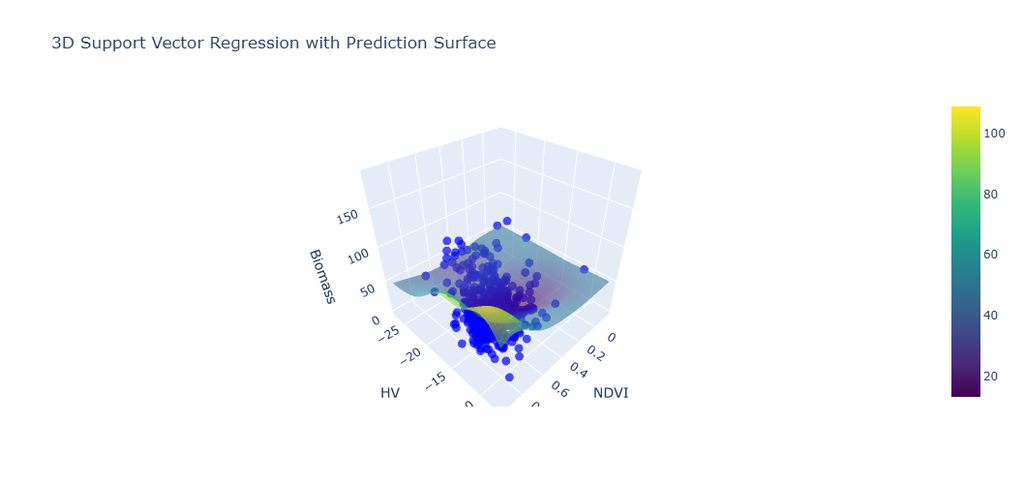

```python
svr(model_df)
```

### Baseline Biomass

RRG will utilize time series analysis to determine the baseline conditions of the project sites at three distinct time periods from t=-8, t=-3, and t=0. This corresponds to 2015, 2020 and 2023.

#### Using the Simple Model (x=SAR HV, y=UN Biomass 2010)

RRG utilized the Jaxa yearly mosaic going back to 2010 for the training models. However, this dataset does not provide data beyond 2020. Despite this, Jaxa provides multiple datasets with more up to date data. RRG will utilize [this dataset](https://developers.google.com/earth-engine/datasets/catalog/JAXA_ALOS_PALSAR_YEARLY_SAR_EPOCH#bands) for baseline biomass analysis.

```python
year = (2015, 2020, 2023)
palsar_images = []
for time in year:
    palsar = ee.ImageCollection('JAXA/ALOS/PALSAR/YEARLY/SAR_EPOCH')\
        .filterDate(f'{time}-01-01', f'{time + 1}-01-01')\
        .filterBounds(projectsites)
    print(f"{time}: {palsar.size().getInfo()} images")
    collection = (
        palsar
        .map(convertToGammaNaught)  # Your preprocessing steps
        .map(applyQualityMask)
    )
    palsarImage = collection.first().clip(projectsites)
    hvImage = palsarImage.select('HV') #Users can select HH or HV
    # Append to list
    palsar_images.append(hvImage)
```

```
2015: 1 images
2020: 1 images
2023: 1 images
```

```python
SARMap = geemap.Map(notebook_display=True)
SARMap.add_basemap('HYBRID')
SARMap.addLayer(palsar_images[0], hvVis, 'HV (db) 2015')
SARMap.addLayer(palsar_images[1], hvVis, 'HV (db) 2020')
SARMap.addLayer(palsar_images[2], hvVis, 'HV (db) 2023')
SARMap.addLayer(projectsites, psiteVis, 'Project Sites')
SARMap.centerObject(projectsites, 10)
SARMap.add_inspector()
```

[figure not shown]

**Load Dataset**

```python
SARts = pd.read_csv('../sheetsTanz/HVBaselineProjectSitesv1.csv')
anova_bc = SARts.copy()
SARts = SARts.drop(SARts.columns[0], axis=1)
SARts.head(1) #includes coordinates for auditing, id corresponding to each project plot
```

|  | HH_2015 | HH_2020 | HH_2023 | SiteName | .geo |
| --- | --- | --- | --- | --- | --- |
| 0 | -13.964271 | -15.731521 | -15.374088 | Baga Ridge 1 | {"geodesic":false,"type":"Point","coordinates":[38.430189778313775,-4.730530741853158]} |

**Biomass Scaling**  
The SAR training models are meant to predict biomass at the hectare level. However, each SAR pixel is only 25m x 25 or 0.0625 hectares. Therefore, RRG scaled each biomass prediction by 0.0625 to get the biomass per pixel

```python
SARts['Biomass_2015'] = (biomass_HV(SARts['HH_2015']) * 0.0625)
SARts['Biomass_2020'] = (biomass_HV(SARts['HH_2020']) * 0.0625)
SARts['Biomass_2023'] = (biomass_HV(SARts['HH_2023']) * 0.0625)
tsDF = SARts.iloc[:,[-1, -2, -3, 3]]
tsDF.head(1)
```

|  | Biomass_2023 | Biomass_2020 | Biomass_2015 | SiteName |
| --- | --- | --- | --- | --- |
| 0 | 2.273055 | 2.155785 | 2.751174 | Baga Ridge 1 |

#### Site Totals

```
                    SiteName  Biomass_2023  Biomass_2020  Biomass_2015
0            Bombo Makole FR      27375.12      27463.44      27267.46
1       Baga II FR - Bumbuli      21494.52      20319.21      20743.01
2                Ndelemai FR      21352.25      21415.70      20864.39
3       Baga II FR - Kwesine      19415.85      18861.49      18685.31
4                  Mtumbi FR      18662.08      19673.50      18550.27
5         Magamba NFR - Kwai      14259.69      14213.43      12980.99
6                       Baga      10272.31      11271.35       9952.61
7                  Mavului 1       8302.52       9149.45       8295.65
8      Magamba NFR - Grewali       8127.26       8089.32       7203.33
9   Magamba NFR - Hambalawei       7764.65       7988.36       7505.79
10    Chambogo FR - Chambogo       6733.52       7109.43       5928.47
11                   Mgwashi       6685.89       7236.28       5997.47
12     Mkussu FR - Kwemashai       5374.92       5712.47       5517.85
13       Mkussu FR - Kwesine       5365.07       5743.53       5233.40
14                    Baga 3       5341.65       6087.78       5227.22
15              Baga Ridge 2       5304.86       5889.80       4719.16
16              Baga Ridge 1       3455.51       3577.38       3013.84
17      Magamba NFR - Sungwi       2997.55       3093.81       3303.92
18      Chambogo FR - Makose       2632.54       2504.12       2337.87
19     Mkussu FR - Kifungiro       1866.02       2233.52       2043.87
20                 Baga I FR       1783.84       1755.56       1750.96
21            Magila-Kitambi        577.92        683.73        563.18
```

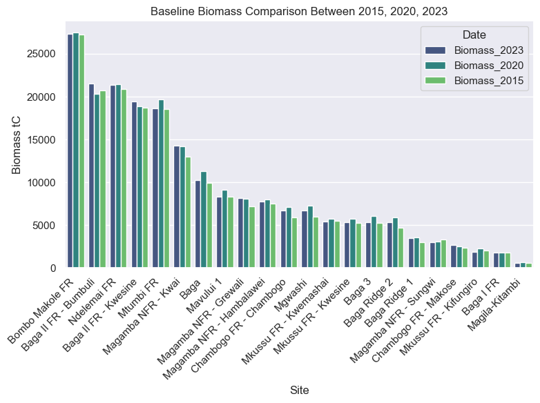

```python
bc_total = tsDF.groupby('SiteName')[['Biomass_2023', 'Biomass_2020', 'Biomass_2015']].sum().sort_values(by='Biomass_2023', ascending=False)
bc_final = bc_total.reset_index().round(decimals=2)
print(bc_final)
# Melt to long-form for Seaborn
df_melted = pd.melt(bc_final,
                    id_vars='SiteName',
                    value_vars=['Biomass_2023', 'Biomass_2020', 'Biomass_2015'],
                    var_name='Date',
                    value_name='Biomass')
# Plot
plt.figure(figsize=(8, 6))
sns.set_theme()
sns.barplot(data=df_melted, x='SiteName', y='Biomass', hue='Date', palette="viridis")
plt.xlabel('Site')
plt.xticks(rotation=45, ha='right')
plt.ylabel('Biomass tC')
plt.title('Baseline Biomass Comparison Between 2015, 2020, 2023')
plt.tight_layout()
sns.set_theme()
plt.show()
```

#### Average Biomass Per Hectare Per Site

```python
pSites = pd.read_csv('./sheetsTanz/nurserlogEXPORT.csv')
pExp = pSites.iloc[:, [1,2]].round(2)
pExp.columns.values[0] = 'SiteName'
mergepSite = pd.merge(t, pExp, on='SiteName')
mergepSite['Avg Biomass/ha 2023'] = mergepSite.iloc[:,1] / mergepSite.iloc[:,4]
mergepSite['Avg Biomass/ha 2020'] = mergepSite.iloc[:,2] / mergepSite.iloc[:,4]
mergepSite['Avg Biomass/ha 2015'] = mergepSite.iloc[:,3] / mergepSite.iloc[:,4]
mergepSite.sort_values(by='Avg Biomass/ha 2023', ascending=False).head()
```

|  | SiteName | Biomass_2023 | Biomass_2020 | Biomass_2015 | KMZ Area (ha) | Avg Biomass/ha 2023 | Avg Biomass/ha 2020 | Avg Biomass/ha 2015 |
| --- | --- | --- | --- | --- | --- | --- | --- | --- |
| 2 | Baga II FR - Kwesine | 19415.85 | 18861.49 | 18685.31 | 327.53 | 59.279608 | 57.587061 | 57.049156 |
| 1 | Ndelemai FR | 21352.25 | 21415.70 | 20864.39 | 367.00 | 58.180518 | 58.353406 | 56.851199 |
| 9 | Mkussu FR - Kwemashai | 5374.92 | 5712.47 | 5517.85 | 97.07 | 55.371588 | 58.848975 | 56.844030 |
| 0 | Bombo Makole FR | 27375.12 | 27463.44 | 27267.46 | 496.11 | 55.179537 | 55.357562 | 54.962528 |
| 3 | Magamba NFR - Kwai | 14259.69 | 14213.43 | 12980.99 | 268.06 | 53.195889 | 53.023316 | 48.425688 |

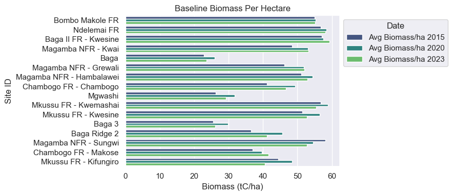

```python
#vizualize change in tC/ha
change = mergepSite.iloc[:, [0, -1, -2, -3]].copy()
# Melt DataFrame: id on y-axis, biomass values on x-axis
df_melted = pd.melt(
    change,
    id_vars='SiteName',
    value_vars=change.columns[1:],  # skip 'id', melt other columns
    var_name='Date',
    value_name='Biomass'
)
# Plot
plt.figure(figsize=(9, 4))
ax = sns.barplot(
    data=df_melted,
    x='Biomass',   # biomass on x-axis
    y='SiteName',        # site ID on y-axis
    hue='Date',
    palette="viridis",
    orient='h'
)
sns.move_legend(ax, "upper left" , bbox_to_anchor=(1, 1))
plt.xlabel('Biomass (tC/ha)')
plt.ylabel('Site ID')
plt.title('Baseline Biomass Per Hectare')
plt.tight_layout()
plt.show()
```

### Current Biomass

**Data Collection**  
RRG will update biomass estimates per quarter. [Click Here](https://developers.google.com/earth-engine/datasets/catalog/JAXA_ALOS_PALSAR-2_Level2_2_ScanSAR) for the PALSAR dataset.

```python
year = (2023, 2025)
palsar_images = []
for time in year:
    palsar = ee.ImageCollection('JAXA/ALOS/PALSAR-2/Level2_2/ScanSAR')\
        .filterDate(f'{time}-06-01', f'{time}-07-01')\
        .filterBounds(projectsites)
    print(f"{time}: {palsar.size().getInfo()} images")
    collection = (
        palsar
        .map(convertToGammaNaught)  # Your preprocessing steps
    )
    palsarImage = collection.median().clip(projectsites)
    hvImage = palsarImage.select('HV') #Users can select HH or HV
    # Append to list
    palsar_images.append(hvImage)
```

```
2023: 4 images
2025: 4 images
```

```python
SARMap = geemap.Map(notebook_display=True)
SARMap.add_basemap('HYBRID')
SARMap.addLayer(palsar_images[0], hvVis, 'HV (db) 2023')
SARMap.addLayer(palsar_images[1], hvVis, 'HV (db) 2025')
SARMap.addLayer(projectsites, psiteVis, 'Project Sites')
SARMap.centerObject(projectsites, 10)
SARMap.add_inspector()
```

[figure not shown]

#### Visualize Change from Pre to Post Project Activities

```
                    SiteName  Biomass_2023  Biomass_2025
0            Bombo Makole FR      27375.12      25504.98
1       Baga II FR - Bumbuli      21494.52      20079.52
2                Ndelemai FR      21352.25      21386.93
3       Baga II FR - Kwesine      19415.85      18245.15
4                  Mtumbi FR      18662.08      18765.13
5         Magamba NFR - Kwai      14259.69      15555.71
6                       Baga      10272.31      13013.81
7                  Mavului 1       8302.52       8668.59
8      Magamba NFR - Grewali       8127.26       9489.19
9   Magamba NFR - Hambalawei       7764.65       8343.78
10    Chambogo FR - Chambogo       6733.52       7508.70
11                   Mgwashi       6685.89       7372.99
12     Mkussu FR - Kwemashai       5374.92       5625.62
13       Mkussu FR - Kwesine       5365.07       5351.17
14                    Baga 3       5341.65       5817.22
15              Baga Ridge 2       5304.86       6643.17
16              Baga Ridge 1       3455.51       3583.46
17      Magamba NFR - Sungwi       2997.55       3164.22
18      Chambogo FR - Makose       2632.54       3281.43
19     Mkussu FR - Kifungiro       1866.02       2432.04
20                 Baga I FR       1783.84       1667.44
21            Magila-Kitambi        577.92        771.76
```

[figure not shown]

```python
current = pd.read_csv('./sheetsTanz/HVCurrentProjectSitesv2.csv')
anova_df = current.iloc[:,[3,1,2]]
ad_df = current.iloc[:,[3,2]]
ad_df['Biomass_2025'] = (biomass_HV(ad_df['HH_2025']) * 0.0625)
ad_total = ad_df.groupby('SiteName')\
    [['Biomass_2025']].sum().sort_values(by='Biomass_2025', ascending=False)
ad_final = ad_total.reset_index().round(decimals=2)
ad_final.head()
comps = pd.merge(bc_final, ad_final, on='SiteName').iloc[:,[0,1,-1]]
print(comps)
df_melted = pd.melt(comps,
                    id_vars='SiteName',
                    value_vars=['Biomass_2023', 'Biomass_2025'],
                    var_name='Date',
                    value_name='Biomass')
# Plot
plt.figure(figsize=(8, 6))
sns.barplot(data=df_melted, x='SiteName', y='Biomass', hue='Date', palette="viridis")
plt.xlabel('Site')
plt.xticks(rotation=45, ha='right')
plt.ylabel('Biomass tC')
plt.title('Baseline Biomass Comparison Between 2015, 2020, 2023')
plt.tight_layout()
sns.set_theme()
plt.show()
```

#### ANOVA Testing

Throughout the project lifetime, RRG will utilize ANOVA, or Analysis of Variance, to statistically test to determine if there are significant differences between the mean HV values pre to post planting. It is assumed that as seedlings grow, their HV values increase.

```python
# Find mean HV values for each year
mean_ad = anova_df.groupby('SiteName')[['HH_2023', 'HH_2025']].median().reset_index()
comp_anova = mean_ad
comp_anova.columns.values[0]='Site'
comp_anova.columns.values[1]='Mean HV 2023'
comp_anova.columns.values[2]='Mean HV 2025'
df_long = pd.melt(anova_df, id_vars='SiteName', value_vars=['HH_2023', 'HH_2025'],
                  var_name='Year', value_name='HH_Value')
def anova_two_years(site_df):
    group1 = site_df['HH_2023']
    group2 = site_df['HH_2025']
    f_stat, p_val = f_oneway(group1, group2)
    return pd.Series({'F_stat': f_stat, 'p_value': p_val})

anova_result = anova_df.groupby('SiteName').apply(anova_two_years).reset_index()
anova_result.columns.values[0]='Site'
anova_merge = pd.merge(anova_result, comp_anova, on='Site')
anova_merge = anova_merge.iloc[:,[0,3,4,1,2]]
# Set pandas options for nicer table display in console/notebook
pd.set_option('display.max_rows', 50)
pd.set_option('display.max_columns', None)
pd.set_option('display.precision', 2)
print(anova_merge)
```

[output not shown]

#### Interpreting Results

With this ANOVA test, RRG can statistically validate the difference in HV values from 2023 to 2025. RRG understands this test only included two years. In the near future, RRG will expand this analysis to include a broad range of years.

### Model Performance Discussion

RRG can estimate historical biomass and future biomass of the project area utilizing SI and machine learning. RRG understands that model performance varies between datasets and that improvements can be made. Moving into the future, RRG will include model updates for the following categories:

RRG understands the importance of accurate remote sensing and field monitoring systems to quantify biomass changes throughout the project lifetime. This document will serve as a living library and will be updated as RRG makes upgrades.